The plot shows some relationships in a the `diamonds` data.

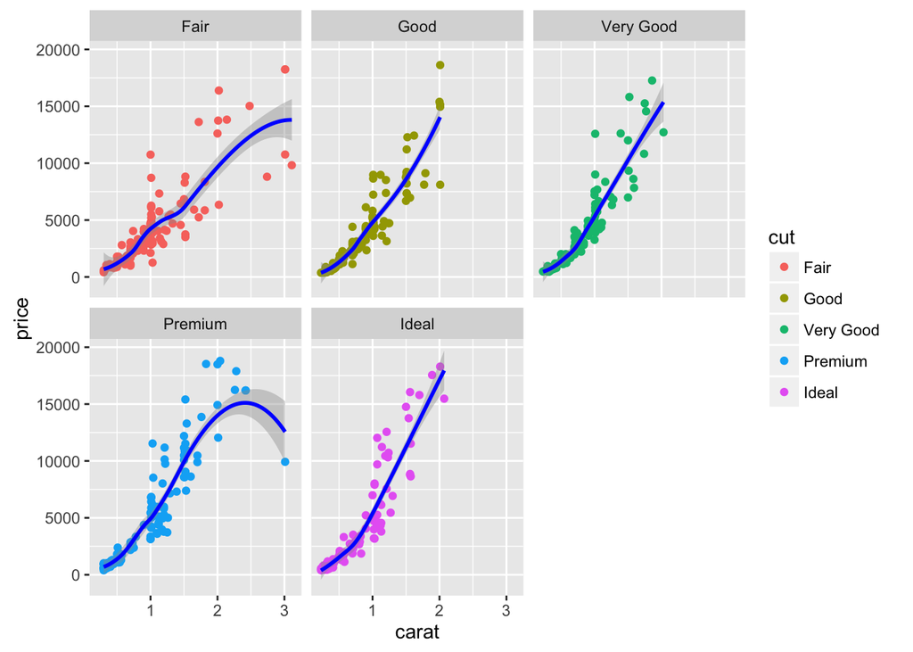

The glyph-ready data are in this format:

```
## Source: local data frame [6 x 10]
## Groups: cut [1]
##
##   carat   cut color clarity depth table price     x     y     z
##   <dbl> <ord> <ord>   <ord> <dbl> <dbl> <int> <dbl> <dbl> <dbl>
## 1  1.27  Fair     H     SI2  65.2    54  5334  6.78  6.71  4.41
## 2  1.03  Fair     G     SI2  65.7    59  2942  6.30  6.24  4.12
## 3  0.39  Fair     G      IF  57.1    61  1127  4.83  4.88  2.77
## 4  0.47  Fair     I     VS2  57.1    61   919  5.11  5.15  2.93
## 5  0.90  Fair     E     SI1  59.2    60  4220  6.17  6.22  3.67
## 6  1.45  Fair     J     SI2  58.6    68  4570  7.45  7.33  4.34
```

1. What layers are on the graph? For each layer, say whether the glyph reflects a single case or the collective properties of cases (a statistic). Two layers:
   1. Glyphs are dots. Each dot represents a single case.
   2. A smoother through the dots. This is a statistic and shows collective properties of the cases.
2. What variables are being used in the graphic? `caret`, `price`, and `cut`
3. Which variables define the frame? `price` vs `carat`
4. Which variable or variables are being used to define facets? `cut` defines the facets.
5. What are the aesthetics used? For each aesthetic, say which variable is being mapped to it or what constant it is being set to.
   - x: `carat`
   - y: `price`
   - color (of points): `cut`
   - color of smoother: set to blue
6. Assuming that the relevant packages are already loaded, write down a `ggplot()` command that will generate the graphic.

```r
diamonds %>%
  ggplot(aes(x = carat, y = price, color = cut)) +
  geom_point() +
  stat_smooth(color = "blue") +
  facet_wrap( ~ cut)
```